# Are Players Getting Paid Accurately

## Packages

```python
%matplotlib inline
```

```python
import pandas as pd
import numpy as np
import matplotlib.pyplot as plt
import seaborn as sns
from scipy.stats import skew
import warnings
from sklearn.ensemble import RandomForestClassifier
from sklearn.model_selection import train_test_split, cross_val_score
from sklearn.metrics import accuracy_score, roc_auc_score, f1_score, classification_report
from sklearn.ensemble import GradientBoostingClassifier
from imblearn.over_sampling import SMOTE
from xgboost import XGBClassifier
```

```python
warnings.filterwarnings('ignore')
warnings.filterwarnings("ignore", category=UserWarning)
warnings.filterwarnings("ignore", category=FutureWarning)
warnings.filterwarnings("ignore", category=Warning)
```

## Merging data

```python
# Load the datasets
batting_df = pd.read_csv('/content/statcast_batting.csv')
pitching_df = pd.read_csv('/content/pitching_statcast.csv')
contracts_df = pd.read_csv('/content/contracts.csv')

# Split "last_name, first_name" in the batting and pitching Statcast data
batting_df[['last_name', 'first_name']] = batting_df['last_name, first_name'].str.split(', ', expand=True)
pitching_df[['last_name', 'first_name']] = pitching_df['last_name, first_name'].str.split(', ', expand=True)

# Drop the original combined name columns
batting_df.drop(columns=['last_name, first_name'], inplace=True)
pitching_df.drop(columns=['last_name, first_name'], inplace=True)

# Update pitching positions in contracts_df to a general "pitcher" category
pitching_positions = ['rhp-s', 'lhp-s', 'rhp-c', 'lhp-c', 'rhp', 'lhp']
contracts_df['position'] = contracts_df['position'].replace(dict.fromkeys(pitching_positions, 'pitcher'))

# Split contracts into pitching and batting based on the updated position
pitching_contracts = contracts_df[contracts_df['position'] == 'pitcher']
batting_contracts = contracts_df[contracts_df['position'] != 'pitcher']

# Merge pitching contracts with pitching Statcast data
merged_pitching = pd.merge(pitching_contracts, pitching_df, on=['first_name', 'last_name', 'year'], how='inner')

# Merge batting contracts with batting Statcast data
merged_batting = pd.merge(batting_contracts, batting_df, on=['first_name', 'last_name', 'year'], how='inner')

# Display the first few rows of each merged dataset to confirm
print("Merged Pitching Dataset:")
print(merged_pitching.head())

print("\nMerged Batting Dataset:")
print(merged_batting.head())
```

```
Merged Pitching Dataset:
   Unnamed: 0 first_name last_name       team  year position     age  \
0           7    Framber    Valdez    Houston  2024  pitcher      30
1          22     Hunter     Brown    Houston  2024  pitcher      25
2          28      Ronel    Blanco    Houston  2024  pitcher      30
3          37      Shane    Bieber  Cleveland  2023  pitcher  28.031
4          44      Aaron    Civale  Cleveland  2023  pitcher  28.019

   service time           agent    value  ...  n_ff_formatted  ff_avg_speed  \
0         4.163         Octagon  12.1000  ...             1.2          94.5
1         1.035             NaN   0.7745  ...            34.7          96.0
2         0.101             NaN   0.7498  ...            38.3          93.4
3         4.097  Rosenhaus Spts  10.0100  ...            35.2          91.3
4         3.058             NaN   2.6000  ...            12.3          91.8

   ff_avg_spin  n_sl_formatted  sl_avg_speed  n_ch_formatted  ch_avg_speed  \
0       2152.0             4.3          85.1            17.5          89.9
1       2297.0             5.2          89.2            12.6          88.4
2       2228.0            30.2          86.4            22.1          85.2
3       2242.0            20.7          84.6             3.5          87.2
4       2384.0             5.8          82.5             NaN           NaN

   n_cu_formatted  cu_avg_speed  cu_avg_spin
0            31.3          79.7       2905.0
1            12.5          82.9       2486.0
2             9.4          80.1       2258.0
3            13.7          82.5       2239.0
4            24.4          78.1       2985.0

[5 rows x 55 columns]

Merged Batting Dataset:
   Unnamed: 0 first_name last_name     team  year position age  service time  \
0           1       Alex   Bregman  Houston  2024       3b  30         7.070
1           2       Jose    Altuve  Houston  2024       2b  34        12.072
2          10     Yordan   Alvarez  Houston  2024    lf-dh  27         4.113
3          21     Jeremy      Peña  Houston  2024       ss  26         2.000
4          23     Yainer      Diaz  Houston  2024        c  25         1.035

         agent      value  ...  hard_hit_percent  avg_best_speed  \
0  Boras Corp.  30.500000  ...              40.5       98.986528
1  Boras Corp.  29.200000  ...              31.2       97.323673
2   MVP Sports  10.833333  ...              49.7      104.097105
3          NaN   0.783500  ...              38.8       99.323507
4          NaN   0.768900  ...              47.5      101.297056

   avg_hyper_speed  z_swing_percent  z_swing_miss_percent  oz_swing_percent  \
0        93.684161             65.6                   8.7              23.6
1        92.693763             68.6                  12.6              37.3
2        96.703520             68.0                  11.1              30.5
3        93.741684             72.9                  11.4              36.9
4        95.034360             77.7                  13.6              42.6

   oz_swing_miss_percent  oz_contact_percent  whiff_percent  swing_percent
0                   24.7                75.3           12.8           44.9
1                   36.1                62.7           21.9           51.5
2                   36.5                63.5           19.9           47.8
3                   49.4                49.7           24.9           54.2
4                   40.2                59.8           24.0           58.8

[5 rows x 48 columns]
```

## Data Cleanup

**Remove Agent**

```python
# Remove the 'agent' column from both merged datasets
merged_pitching = merged_pitching.drop(columns=['agent'])
merged_batting = merged_batting.drop(columns=['agent'])
```

### Missing Values

```python
# Calculate missing values and their percentage of total data for both datasets
missing_values_pitching = merged_pitching.isnull().sum()
missing_values_batting = merged_batting.isnull().sum()

# Filter to show only columns with missing values, including their percentage
missing_values_pitching = missing_values_pitching[missing_values_pitching > 0]
missing_percentage_pitching = (missing_values_pitching / len(merged_pitching)) * 100

missing_values_batting = missing_values_batting[missing_values_batting > 0]
missing_percentage_batting = (missing_values_batting / len(merged_batting)) * 100

# Display columns with missing values, their counts, and percentage
print("Missing values in Merged Pitching Dataset:")
print(pd.DataFrame({'Missing Values': missing_values_pitching, 'Percentage': missing_percentage_pitching}))

print("\nMissing values in Merged Batting Dataset:")
print(pd.DataFrame({'Missing Values': missing_values_batting, 'Percentage': missing_percentage_batting}))
```

```
Missing values in Merged Pitching Dataset:
                Missing Values  Percentage
n_ff_formatted              16    3.539823
ff_avg_speed                16    3.539823
ff_avg_spin                 16    3.539823
n_sl_formatted             102   22.566372
sl_avg_speed               102   22.566372
n_ch_formatted              64   14.159292
ch_avg_speed                64   14.159292
n_cu_formatted              70   15.486726
cu_avg_speed                70   15.486726
cu_avg_spin                 70   15.486726

Missing values in Merged Batting Dataset:
                    Missing Values  Percentage
avg_swing_speed                459   78.865979
fast_swing_rate                459   78.865979
blasts_contact                 459   78.865979
blasts_swing                   459   78.865979
squared_up_contact             459   78.865979
```

**Remove data with over 75% of missing data**

```python
# Define threshold for missing percentage
threshold = 75

# Filter columns with missing percentage over threshold for removal
columns_to_remove_pitching = missing_percentage_pitching[missing_percentage_pitching > threshold].index
columns_to_remove_batting = missing_percentage_batting[missing_percentage_batting > threshold].index

# Drop these columns from the datasets
merged_pitching = merged_pitching.drop(columns=columns_to_remove_pitching)
merged_batting = merged_batting.drop(columns=columns_to_remove_batting)

# Display the remaining columns to confirm removal
print("Columns in Merged Pitching Dataset after removal:")
print(merged_pitching.columns)

print("\nColumns in Merged Batting Dataset after removal:")
print(merged_batting.columns)
```

```
Columns in Merged Pitching Dataset after removal:
Index(['Unnamed: 0', 'first_name', 'last_name', 'team', 'year', 'position',
       'age', 'service time', 'value', 'player_id', 'pa', 'home_run',
       'strikeout', 'k_percent', 'bb_percent', 'batting_avg', 'slg_percent',
       'p_era', 'xwoba', 'sweet_spot_percent', 'barrel', 'barrel_batted_rate',
       'solidcontact_percent', 'hard_hit_percent', 'avg_hyper_speed',
       'z_swing_percent', 'z_swing_miss_percent', 'oz_swing_percent',
       'oz_swing_miss_percent', 'oz_contact_percent', 'out_zone_swing_miss',
       'meatball_swing_percent', 'meatball_percent', 'pitch_count_offspeed',
       'pitch_count_fastball', 'pitch_count_breaking', 'pitch_count',
       'iz_contact_percent', 'in_zone_swing_miss', 'whiff_percent',
       'swing_percent', 'pitch_hand', 'n', 'arm_angle', 'n_ff_formatted',
       'ff_avg_speed', 'ff_avg_spin', 'n_sl_formatted', 'sl_avg_speed',
       'n_ch_formatted', 'ch_avg_speed', 'n_cu_formatted', 'cu_avg_speed',
       'cu_avg_spin'],
      dtype='object')

Columns in Merged Batting Dataset after removal:
Index(['Unnamed: 0', 'first_name', 'last_name', 'team', 'year', 'position',
       'age', 'service time', 'value', 'player_id', 'pa', 'hit', 'home_run',
       'walk', 'k_percent', 'bb_percent', 'batting_avg', 'slg_percent',
       'on_base_percent', 'on_base_plus_slg', 'isolated_power', 'babip',
       'b_rbi', 'woba', 'xwoba', 'wobacon', 'xwobacon', 'xbacon',
       'exit_velocity_avg', 'sweet_spot_percent', 'barrel_batted_rate',
       'solidcontact_percent', 'hard_hit_percent', 'avg_best_speed',
       'avg_hyper_speed', 'z_swing_percent', 'z_swing_miss_percent',
       'oz_swing_percent', 'oz_swing_miss_percent', 'oz_contact_percent',
       'whiff_percent', 'swing_percent'],
      dtype='object')
```

```python
# Drop the "Unnamed: 0" column from both merged datasets if it exists
merged_pitching = merged_pitching.drop(columns=['Unnamed: 0'], errors='ignore')
merged_batting = merged_batting.drop(columns=['Unnamed: 0'], errors='ignore')

# Display the first few rows to confirm removal
print("Merged Pitching Dataset after removing 'Unnamed: 0':")
print(merged_pitching.head())

print("\nMerged Batting Dataset after removing 'Unnamed: 0':")
print(merged_batting.head())
```

```
Merged Pitching Dataset after removing 'Unnamed: 0':
  first_name last_name       team  year position     age  service time  \
0    Framber    Valdez    Houston  2024  pitcher      30         4.163
1     Hunter     Brown    Houston  2024  pitcher      25         1.035
2      Ronel    Blanco    Houston  2024  pitcher      30         0.101
3      Shane    Bieber  Cleveland  2023  pitcher  28.031         4.097
4      Aaron    Civale  Cleveland  2023  pitcher  28.019         3.058

     value  player_id   pa  ...  n_ff_formatted  ff_avg_speed  ff_avg_spin  \
0  12.1000     664285  703  ...             1.2          94.5       2152.0
1   0.7745     686613  712  ...            34.7          96.0       2297.0
2   0.7498     669854  676  ...            38.3          93.4       2228.0
3  10.0100     669456  533  ...            35.2          91.3       2242.0
4   2.6000     650644  504  ...            12.3          91.8       2384.0

   n_sl_formatted  sl_avg_speed  n_ch_formatted  ch_avg_speed  n_cu_formatted  \
0             4.3          85.1            17.5          89.9            31.3
1             5.2          89.2            12.6          88.4            12.5
2            30.2          86.4            22.1          85.2             9.4
3            20.7          84.6             3.5          87.2            13.7
4             5.8          82.5             NaN           NaN            24.4

   cu_avg_speed  cu_avg_spin
0          79.7       2905.0
1          82.9       2486.0
2          80.1       2258.0
3          82.5       2239.0
4          78.1       2985.0

[5 rows x 53 columns]

Merged Batting Dataset after removing 'Unnamed: 0':
  first_name last_name     team  year position age  service time      value  \
0       Alex   Bregman  Houston  2024       3b  30         7.070  30.500000
1       Jose    Altuve  Houston  2024       2b  34        12.072  29.200000
2     Yordan   Alvarez  Houston  2024    lf-dh  27         4.113  10.833333
3     Jeremy      Peña  Houston  2024       ss  26         2.000   0.783500
4     Yainer      Diaz  Houston  2024        c  25         1.035   0.768900

   player_id   pa  ...  hard_hit_percent  avg_best_speed  avg_hyper_speed  \
0     608324  634  ...              40.5       98.986528        93.684161
1     514888  682  ...              31.2       97.323673        92.693763
2     670541  635  ...              49.7      104.097105        96.703520
3     665161  650  ...              38.8       99.323507        93.741684
4     673237  619  ...              47.5      101.297056        95.034360

   z_swing_percent  z_swing_miss_percent  oz_swing_percent  \
0             65.6                   8.7              23.6
1             68.6                  12.6              37.3
2             68.0                  11.1              30.5
3             72.9                  11.4              36.9
4             77.7                  13.6              42.6

   oz_swing_miss_percent  oz_contact_percent  whiff_percent  swing_percent
0                   24.7                75.3           12.8           44.9
1                   36.1                62.7           21.9           51.5
2                   36.5                63.5           19.9           47.8
3                   49.4                49.7           24.9           54.2
4                   40.2                59.8           24.0           58.8

[5 rows x 41 columns]
```

### Impute rest

```python
# Function to impute missing values based on skewness
def impute_missing_data(df):
    for column in df.columns:
        if df[column].isnull().sum() > 0:  # Check if there are missing values
            # Calculate skewness
            column_skewness = skew(df[column].dropna())

            # Impute based on skewness
            if column_skewness > 0.5:  # Right-skewed, use median
                df[column].fillna(df[column].median(), inplace=True)
            else:  # Fairly normal or left-skewed, use mean
                df[column].fillna(df[column].mean(), inplace=True)

# Apply imputation to both merged datasets
impute_missing_data(merged_pitching)
impute_missing_data(merged_batting)

# Check if any missing values remain in both datasets
missing_after_imputation_pitching = merged_pitching.isnull().sum().sum()
missing_after_imputation_batting = merged_batting.isnull().sum().sum()

print("Remaining missing values in Merged Pitching Dataset:", missing_after_imputation_pitching)
print("Remaining missing values in Merged Batting Dataset:", missing_after_imputation_batting)
```

```
Remaining missing values in Merged Pitching Dataset: 0
Remaining missing values in Merged Batting Dataset: 0
```

## EDA

### Hitting EDA

**Distribution of target variable

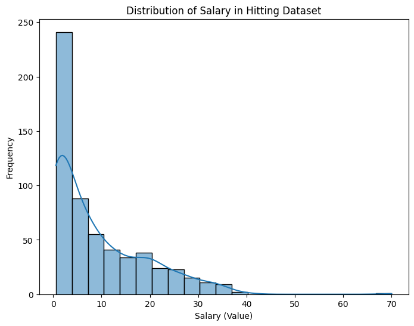

```python
# 1. Distribution of Target Variable (e.g., Salary Value)
plt.figure(figsize=(8, 6))
sns.histplot(merged_batting['value'], kde=True)
plt.title("Distribution of Salary in Hitting Dataset")
plt.xlabel("Salary (Value)")
plt.ylabel("Frequency")
plt.show()
```

Because gradient boost and other ensemble methods are great for handling imbalanced datasets, they will allow us to focus on the hard to predict instance which will be able to capture patterns in minority classes without requiring a perfect class imbalance.

Due to this sku, I might actually benefit from using a top 25% threshold approach to create the target variable, as it aligns wiht the natural skuew in the salaries and helps focus on identifying the truly high earners.

```python
# Confirm there are no missing values in the 'value' column before proceeding
print("Missing values in 'value' column before creating 'top_earner':", merged_batting['value'].isnull().sum())

# Re-calculate the 75th percentile salary as the threshold for top earners
top_25_salary = merged_batting['value'].quantile(0.75)

# Create binary salary variable: 1 for top 25% earners, 0 for others
# This ensures that no NaNs are introduced by using >= to include exact 75th percentile salaries
merged_batting['top_earner'] = (merged_batting['value'] >= top_25_salary).astype(int)

# Check for any NaNs in the 'top_earner' column after creation
print("Missing values in 'top_earner' after creation:", merged_batting['top_earner'].isnull().sum())
```

```
Missing values in 'value' column before creating 'top_earner': 0
Missing values in 'top_earner' after creation: 0
```

### Pitching EDA

**Distribution of target var**

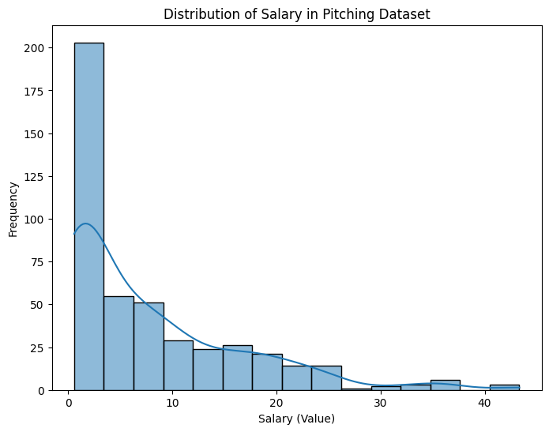

```python
# 1. Distribution of Target Variable (e.g., Salary Value)
plt.figure(figsize=(8, 6))
sns.histplot(merged_pitching['value'], kde=True)
plt.title("Distribution of Salary in Pitching Dataset")
plt.xlabel("Salary (Value)")
plt.ylabel("Frequency")
plt.show()
```

Same sku here so will do the same thing.

```python
# Confirm there are no missing values in the 'value' column before proceeding
print("Missing values in 'value' column before creating 'top_earner':", merged_pitching['value'].isnull().sum())

# Re-calculate the 75th percentile salary as the threshold for top earners
top_25_salary = merged_pitching['value'].quantile(0.75)

# Create binary salary variable: 1 for top 25% earners, 0 for others
# This ensures that no NaNs are introduced by using >= to include exact 75th percentile salaries
merged_pitching['top_earner'] = (merged_pitching['value'] >= top_25_salary).astype(int)

# Check for any NaNs in the 'top_earner' column after creation
print("Missing values in 'top_earner' after creation:", merged_pitching['top_earner'].isnull().sum())
```

```
Missing values in 'value' column before creating 'top_earner': 0
Missing values in 'top_earner' after creation: 0
```